# Tipologia y ciclo de vida de los datos - PRA2

### 3.2.3 Regresión logistica

Con el objetivo de tener un modelo que nos permitiera tener un control de calidad excluyente que nos permitiera decidir si el producto final es bueno o malo. Vamos a crear un modelo de regresión logística y compararemos resultados.

```r
# Creamo una variable calidad de tipo factor
datos_clean$quality_factor <- as.factor(datos_clean$quality)

# Creamos un variable calidad binomial
datos_clean$category[datos_clean$quality <= 5] <- 0
datos_clean$category[datos_clean$quality > 5] <- 1
datos_clean$category <- as.factor(datos_clean$category)
```

```r
# Generamos el modelo
modelo_log <- glm(category ~ alcohol + sulphates + volatile.acidity, data = datos_clean, family = "binomial")
summary(modelo_log)
```

```
##
## Call:
## glm(formula = category ~ alcohol + sulphates + volatile.acidity,
##     family = "binomial", data = datos_clean)
##
## Deviance Residuals:
##     Min       1Q   Median       3Q      Max
## -2.6924  -0.8389   0.2923   0.8382   2.3321
##
## Coefficients:
##                   Estimate Std. Error z value Pr(>|z|)
## (Intercept)      -12.47164    1.11249 -11.211  < 2e-16 ***
## alcohol            1.02284    0.09456  10.817  < 2e-16 ***
## sulphates          5.29518    0.77638   6.820 9.08e-12 ***
## volatile.acidity  -2.29750    0.49250  -4.665 3.09e-06 ***
## ---
## Signif. codes:  0 '***' 0.001 '**' 0.01 '*' 0.05 '.' 0.1 ' ' 1
##
## (Dispersion parameter for binomial family taken to be 1)
##
##     Null deviance: 1353.0  on 979  degrees of freedom
## Residual deviance: 1025.2  on 976  degrees of freedom
## AIC: 1033.2
##
## Number of Fisher Scoring iterations: 4
```

Creamos la tabla de confusión correspondiente al modelo.

```r
library(vcd)
predicciones <- ifelse(test = modelo_log$fitted.values > 0.5, yes = 1, no = 0)
matriz_confusion <- table(modelo_log$model$category , predicciones, dnn = c("observaciones", "predicciones"))
matriz_confusion
```

```
##              predicciones
## observaciones   0   1
##             0 344 109
##             1 156 371
```

Visualizamos los resultados.

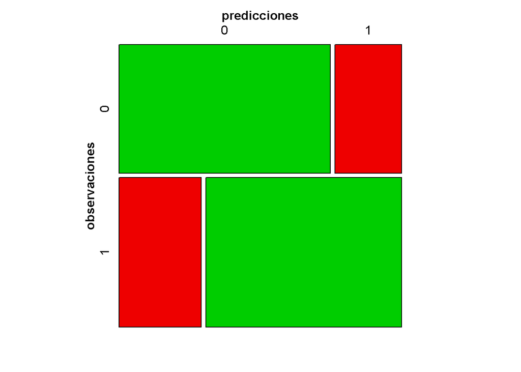

```r
mosaic(matriz_confusion, shade = T, colorize = T, gp = gpar(fill = matrix(c("green3", "red2", "red2", "green3"), 2, 2)))
```

El modelo de regresión logística nos ha dado un resultado de predicción de un 72% de acierto. Hemos de tener en cuenta que hemos simplificado la predicción a dos valores, considerando los vinos con puntuación de 5 o menos como malos y de más de 5 como buenos. En este caso, hemos entrenado el modelo con todos los datos y lo hemos evaluado sobre los mimos datos.

### 3.2.4 Modelos de clasificacion

También nos seria útil tener algún modelo de clasificación que pudiéramos determinar la calidad del vino en función de sus características. Podría agrupar los productos o producción en varios productos de venta, etc… Crearemos un modelo supervisado.

## 3.3 Arbol de decision

Necesitaremos prepara los datos para crear un grupo de datos de entrenamiento y de prueba.

```r
# Copiamos los datos y eliminamos algunas columnas
datos_arbol <- datos_clean
datos_arbol$quality <- NULL
datos_arbol$quality_factor <- NULL
#datos_arbol$category <- NULL


# Creamos los conjuntos de datos de entrenamiento y de test.
set.seed(666)
datos_training <- sample_frac(datos_arbol, .7)
datos_test <- setdiff(datos_arbol, datos_training)
```

Entrenamos el modelo basandonos en la variable categoria

```r
library(rpart)
library(rpart.plot)
arbol <- rpart(formula = category~ ., data = datos_training)
```

Evaluando el modelo

```r
arbol
```

```
## n= 686
##
## node), split, n, loss, yval, (yprob)
##       * denotes terminal node
##
##  1) root 686 301 1 (0.4387755 0.5612245)
##    2) alcohol< 10.45 388 147 0 (0.6211340 0.3788660)
##      4) sulphates< 0.625 253  70 0 (0.7233202 0.2766798)
##        8) volatile.acidity>=0.6525 70   9 0 (0.8714286 0.1285714) *
##        9) volatile.acidity< 0.6525 183  61 0 (0.6666667 0.3333333)
##         18) total.sulfur.dioxide>=41 104  25 0 (0.7596154 0.2403846) *
##         19) total.sulfur.dioxide< 41 79  36 0 (0.5443038 0.4556962)
##           38) free.sulfur.dioxide< 10.5 51  17 0 (0.6666667 0.3333333) *
##           39) free.sulfur.dioxide>=10.5 28   9 1 (0.3214286 0.6785714) *
##      5) sulphates>=0.625 135  58 1 (0.4296296 0.5703704)
##       10) volatile.acidity>=0.565 52  19 0 (0.6346154 0.3653846)
##         20) alcohol< 9.85 33   7 0 (0.7878788 0.2121212) *
##         21) alcohol>=9.85 19   7 1 (0.3684211 0.6315789) *
##       11) volatile.acidity< 0.565 83  25 1 (0.3012048 0.6987952) *
##    3) alcohol>=10.45 298  60 1 (0.2013423 0.7986577)
##      6) sulphates< 0.585 82  34 1 (0.4146341 0.5853659)
##       12) alcohol< 11.1 33  10 0 (0.6969697 0.3030303) *
##       13) alcohol>=11.1 49  11 1 (0.2244898 0.7755102) *
##      7) sulphates>=0.585 216  26 1 (0.1203704 0.8796296) *
```

Mostramos el arbol de desicion con la funcion plot

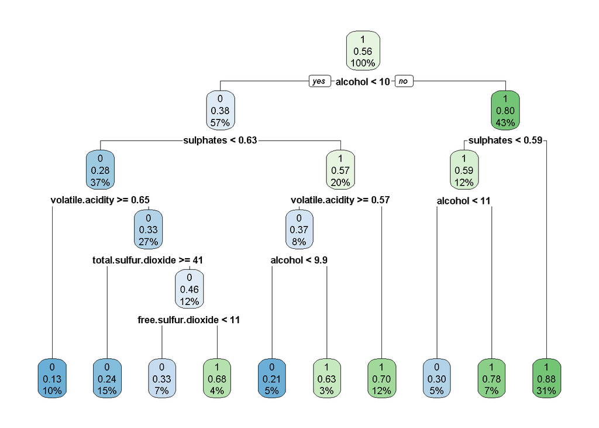

```r
rpart.plot(arbol)
```

Creamos la matrix de confusion para evaluar el arbol.

```r
library(tidyverse)
library(caret)
prediccion <- predict(arbol, newdata = datos_test, type = "class")
confusionMatrix(prediccion, datos_test[["category"]])
```

```
## Confusion Matrix and Statistics
##
##           Reference
## Prediction   0   1
##          0 105  42
##          1  47 100
##
##                Accuracy : 0.6973
##                  95% CI : (0.6413, 0.7493)
##     No Information Rate : 0.517
##     P-Value [Acc > NIR] : 2.484e-10
##
##                   Kappa : 0.3946
##
##  Mcnemar's Test P-Value : 0.6716
##
##             Sensitivity : 0.6908
##             Specificity : 0.7042
##          Pos Pred Value : 0.7143
##          Neg Pred Value : 0.6803
##              Prevalence : 0.5170
##          Detection Rate : 0.3571
##    Detection Prevalence : 0.5000
##       Balanced Accuracy : 0.6975
##
##        'Positive' Class : 0
##
```

Vemos que la presicion del modelo es 69.73%. Con un valor del factor Kappa de 0.3946

[output not shown]